# Primate Data Exchange (PRIME-DE) Request for Information Results

Last updated: 28 August, 2019

## **About the PRIME-DE Global Collaboration Workshop**

[figure not shown]

To accelerate the pace of advancement, the PRIMatE Data Exchange (PRIME-DE) was recently established to promote a culture of collaboration and open science in the nonhuman primate (NHP) neuroimaging community. Towards this goal, PRIME-DE established a [repository](https://doi.org/10.1016/j.neuron.2018.08.039) of openly shared data in 2017, and more recently, the PRIME-DE [Global Collaboration Workshop (GCW)](http://fcon_1000.projects.nitrc.org/indi/PRIME/Workshop_reg.html), which will take place in London at the Wellcome Trust on September 5th and 6th.

In preparation for the GCW, PRIME-DE distributed a request for information regarding challenges and practices in the NHP imaging community. The survey questions were generated by GCW session co-leaders to probe commonly cited concerns among NHP researchers, though there was also an opportunity to share any questions or areas of concern not included in the survey.

Here, we are happy to share the results of the PRIME-DE Request for Information. Our hope is that the information provided will help to guide future discussions among investigators and stakeholders, as well as facilitate priority setting.

## **Survey Results**

### I) Standardized Paradigm Design

#### If we were to collectively set up a short video movie for use as a common multimodal localizer paradigm across sites:

#### Q1: What elements do you believe are most essential for inclusion in such a movie stimulus (e.g., conspecific individuals, faces, bodies, social and non-social, interactions, vocalizations, other sounds…)?

ID

Response

1

Variety to be more naturalistic

2

faces, objects, complex visual stimuli

3

<no response>

4

N/A

5

- conspecific and human faces / bodies - conspecific and human voices (multiple call types, for human both speech and non speech) - natural sounds (artificial and heterospecific sounds) - tones with different frequencies

6

Auditory metronome ( brief tones (500Hz, 40 ms, 65 dBs) with an interstimulus interval od 550 or 850 ms.

7

N/A

8

face

9

face, object, motion, social, high and low arousal movies

10

N/A

11

N/A

12

Shapes would be an obvious choice to map the visual cortex, and faces with different expressions would provide information about emotion processing. The inclusion of specific sounds or sound cues could give insight into auditory information processing.

13

Movies, sounds and stimuli with social and non social features

14

It was quite a laborious process to tailor-making footages. I suggest we can build a library/database by gathering all these footages across different labs. Each lab has to provide a read-me txt file. Then, for parties who are interested we can decide/shortlist a subset for running experiments. The advantage with this approach is that we can make use of what we already have in store. For example, we have put up 2,000 4-6 second long videos up here: http://118.126.113.127/ (just put in random values to get started to view them). These footages are made with the following constraints: 1) the clip must contain a continuous flow of depiction of events (i.e., no scene transition); 2) at least one living creature must be included; 3a) at least one of the animals contained must be in obvious motion; 3b) the trajectories of these motion must be uni-directional (i.e., no back and forth motion of the same subject); 4) clips with snakes were discarded. Half of the clips were with primate content including various species of monkeys, great apes, bonobos, and so on, while the other half with non-primate content including other kinds of mammals, and other phyla such as birds, fish, reptiles, and insects. I can share these videos with interested parties and we can see what we can do from there on.

15

conspecific, faces, vocalizations

16

<no response>

17

N/A

18

Conspesifics that are moving and vocalizing, where you can see the faces. Ideally, it would be nice if the movie included conspecifics in different contexts.

19

<no response>

20

interactions and social and non-social

21

Hand actions/manipulation of objects

22

Faces, Objects, moving dots

23

Maybe a set of localizers could be considered (Each of them being designed to answer a specific question) rather than a broad one that for instance will target social vs rest.

24

I study chemosensory and interoceptive functional processes using paradigms of stimulus application, for such a localizer has not been well established.

25

<no response>

26

N/A

27

Our brains come in jars… no paradigms possible

28

Our brains come in jars. post mortem, no paradigms possible

29

conspecifics (faces+bodies) engaged in social interactions conspecifics (faces+bodies) engaged in non-social interactions: e.g. moving around / foraging / eating / resting etc. vocalization high value non-social items: e.g. food / high value foraging places (inferred from context)

30

- 3 kinds of paradigm inside: event-related ; simple block design & Resting State - at least 2 types of stimulation: visual (retinotopy for instance) and auditory (tonotopy for example). - use same anesthetic if under sedation

31

N/A

32

I have a number of videos that could be of use for this type of localizer from Russ and Leopold 2015. However to expand on those videos, which were not designed as a localizer per se, I would place a greater focus on fluctuations in faces, body parts, colors, and motion. Additionally, I would try to integrate vocalizations and other auditory components better. All of this is going to depend on the length of the video as well, with my original movies face patches were best localized with at least 15 minutes of data, though with a more targeted movie it probably could be done in 8-10.

33

Mainly N/A, in addition to the above, retinotopic mapping localizer.

34

<no response>

35

<no response>

36

N/A

37

I am considering about this topic.

38

Object database, Face database, Social grooming pictures, Conditioned reward stimuli

39

A controlled mix of social and non-social, appetizing, threatening, and neutral close and distant scenes would be one option. I mentioned during the online meeting the work of Liza Bliss-Moreau (UC Davis) who used 300 videos (or 600?) of natural scenes (30 sec each), all rated by ethologists for their ‘emotional’ content. There is also the more recent work of Winrich Freiwald. However, the social/emotional content might complicate interpretation and some may want to suggest rather basic and well characterized dynamic visual stimuli used to study properties of the visual system.

40

N/A

41

Vocalizations, different oro-facial movements, faces

42

individuals, social interactions, vocalizations

43

<no response>

44

<no response>

45

<no response>

46

orientation motion faces actions (grasping, etc) (social) interactions I’m focusing on vision here as sound would in many cases (at least in our case) be tricky to implement just for this purpose.

47

N/A

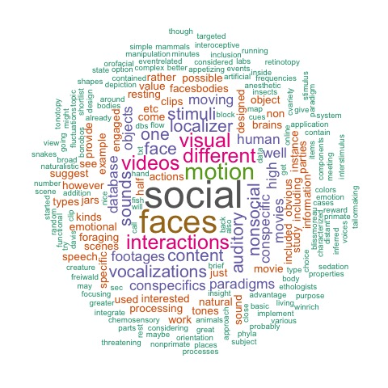

#### Q2: How would you order these elements based on priority?

ID

Response

1

Conspecific, viewing social interactions

2

complex visual stimuli, faces, objects

3

<no response>

4

N/A

5

- conspecific and human voices (multiple call types, for human both speech and non speech) - natural sounds (artificial and heterospecific sounds) - conspecific and human faces / bodies - tones with different frequencies

6

No

7

N/A

8

eye

9

N/A

10

N/A

11

N/A

12

faces, shapes, specific sounds

13

Movies first

14

All these elements are important. What is critical is that the stimuli need to be standardised in terms of duration, resolution, play speed, dimension etc.

15

faces, conspecific, vocalizations

16

<no response>

17

N/A

18

Conspecifics; movment; vocalizatoin; faces; other.

19

<no response>

20

interactions, social and non-social, faces, individuals, bodies

21

Faces and fruits, hand actions, faces, and vocalizations

22

faces - objects - moving dots

23

<no response>

24

Given the list of elements provided I would prioritize social and non-social interactions.

25

<no response>

26

N/A

27

28

29

1. conspecifics (faces+bodies) engaged in social interactions 2. conspecifics (faces+bodies) engaged in non-social interactions: e.g. moving around / foraging / eating / resting etc. 3. high value non-social items: e.g. food / high value foraging places (inferred from context) 4. vocalization

30

<no response>

31

N/A

32

I think this would be difficult to do as the field has a large number of priorities, but for me personally, I would order it as high level features first (Faces, body parts, vocalizations), then down to lower level features like (color, motion, shapes). The higher level features have shown more variability in localization than say MT, so the need for a localizer may be higher.

33

N/A

34

<no response>

35

Would be helpful if localizer included monkey faces, objects, and perhaps bodies.

36

N/A

37

N.A.

38

Conditioned reward stimuli, Object database, Face database, Social grooming pictures

39

I would randomly mix them. The analysis could use tags on scenes to dissociate the different contents and analyze functional connectivity during a single scene across scans/animals/labs.

40

N/A

41

Include stimuli where we already have good data on as control, but also those that are still missing

42

Vision, then sound

43

<no response>

44

<no response>

45

<no response>

46

As above, but open to hypothesis-driven ranking.

47

N/A

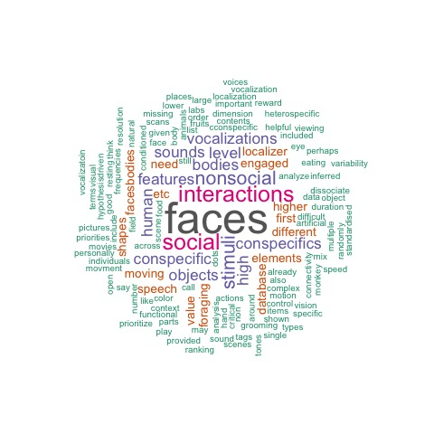

### II) Data Standards, Quality Assessments and Analytic Softwares

#### Q1: What software package(s) do you use for data analysis?

ID

Response

1

FreeSurfer, SPM

2

FSL, python, matlab, ANTs, FreeSurfer, TrackVis

3

FSL, ANTS, AFNI, nipy, nipype

4

NiPype Ants FSL NLM BrainVisa

5

spm fmri stats matlab fsl

6

1a. For surface and volume analysis: ANTS, Freesurfer cross and longitudinal pipeline, Connectome Workbench, CARET, AFNI and CIVET. 1b. For solve the problems of surface and volume analysis software’s: ANTS, Connectome Workbench, mrtrix, CARET, ITKsnap, FSL, mrtrix and BEAST

7

N/A

8

I am pondering about this topic for my data analysis.

9

AFNI, ANTs, FreeSurfer, FSL, Workbench

10

1. We use for surface and volume analysis the next: ANTS, Freesurfer cross and longitudinal pipeline, Connectome Workbench, CARET, AFNI and CIVET. b) For solving the problems of surface and volume analysis softwares: ANTS, Connectome Workbench, mrtrix, CARET, ITKsnap, FSL, mrtrix and BEAST

11

FSL, FreeSurfer

12

FSL, FreeSurfer, ANTs, SPM

13

<no response>

14

SPM

15

fsl, afni

16

afni nipype freesurfer FSL

17

SPM

18

ANTS, AFNI, FSL, DTITK.

19

custom built software with bits from SPM, SPL, Freesurfer, Caret

20

FSl SPM Matlab R studio

21

AFNI/SUMA

22

Freesurfer, FSL, JIP, AFNI

23

FSL Matlab Brain Visa

24

Matlab, SPM, R, AFNI, FSL

25

<no response>

26

FMRIB Software Library, Statistical Parametric Mapping, DTI Studio, DSI Studio, and TrackVis

27

FSL, Freesurfer, ANTS, AFNI, Nilearn, Nipype, CBS tools, Slicer3D, ITK Snap, Segmentator, StereotaxicRAMON, volume, meshgeometry, MeshSurgery, ape, phytools, phylip, rphylopars

28

nilearn, nipype, CBStools, afni, ants, freesurfer,FSL, slicer3D, ITKsnap, segmentator, strereotaxic ramon, volume, meshgeometry,meshsurgery,ape,phytools,phylip,rphylopars,

29

spm fsl jip freesurfer ANTS workbench (and caret) + ad hoc scripts for quality assessment

30

ANTS, FSL, SPM, JIP, nilearn, freesurfer, in-house implementations, etc.

31

AFNI, FSL, custom code (*Please note this applies to rodents - feel free to scrap this from the answer pool if not applicable*)

32

We use a combination of multiple software packages for data analysis, with a majority of our preprocessing steps being run with AFNI, after trial and error with multiple packages. Currently, we are using the nipype python package to run select programs from ANTs, AFNI, and FSL. In addition to this homemade pipeline, we are working on moving our preprocessing pipeline to C-PAC for a more compact package. After preprocessing, we tend to use MATLAB and AFNI for specific data analyses based on the given project.

33

Custom MATLAB code in combination with the NeuroElf (http://neuroelf.net/) BrainVoyager (mainly for visualization) Hauke Kolster’s offline SENSE reconstruction and alignment (only experimental pilot use so far) with JIP (http://www.nmr.mgh.harvard.edu/~jbm/jip/) Plan to combine the MATLAB based NeuroElf pipeline with FSL FLIRT/FNIRT co-registration and TopUp for distortion correction. Planner for implant planning and ephys/microstim/inactivation site reconstructions (https://www.tsaolab.caltech.edu/planner/).

34

SPM, FSL, AntS, AtlasBrex, CMTK

35

AFNI NMT (NIMH Macaque Template) scripts ANTs (and its tissue segmentation tool Atropos) CIVET (macaque version)

36

NHP HCP pipeline (https://github.com/Washington-University/NHPPipelines) Connectome Workbench FSL FreeSurfer

37

I am considering about this topic.

38

FSL, AFNI, ANTs, Elastix, SPM, Conn Toolbox

39

SPM12 Matlab-based scripts developed at MPI-BC My student Renee Hartig has also used AFNI for coreg to 099 based on Reveley et al. (2016), but we prefer in general our own manual registrations, with a GUI developed by Yusuke Murayma (MPI) and later adapted based on our needs. Renee also probably looked at FreeSurfer and other packages.

40

NHP HCP pipeline (https://github.com/Washington-University/NHPPipelines) Connectome Workbench FSL FreeSurfer

41

FSL, wb_command, various python libraries

42

Conn toolbox, preprocessing tools on github.

43

<no response>

44

SPM 12, CONN

45

SPM, Matlab and R

46

dcm2niix Nipype with ANTS, AFNI, and FSL components Freesurfer, ITK-SNAP

47

FreeSurfer, Caret, AFNI, FSL, REST, SPM, ANTs, and code from research papers, custom-written code if none is available.

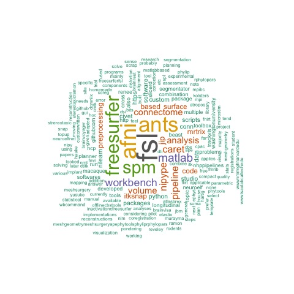

#### Q2: What hacks were required to make these packages work for NHP data?

ID

Response

1

Additional pre-processing, still figuring this out

2

Manual brain extraction correction. For awake data - slice-by-slice non-linear correction for dynamic distortions of the field.

3

Extensive tweaking of FSL and ANTS parameters to achieve appropriate registrations

4

We made a segmentation pipeline that mixes various software to achieve a proper segmentation. Some essentials from this pipeline are: - segmentation is registration based, so it needs an atals with tissue priors. - field of view must be cropped fin order to guarantee good registration.

5

na

6

1. Resolution in the header of the images b) Brain extration c) Dura and brain segmentation d) Bias field correction e) Atlas registration for volume and surface f) Segmentation of subcortical structures g) Other steps for avoid the manual correction

7

N/A

8

What hacks were required to make these packages work for NHP data?

9

1. Manually skull stripping and correction of the segmentation. 2. fake the size of NHP image data to avoid losing the resolution for FreeSurfer pipeline. 3. Create the gender-, site-specific template to facilitate the preprocessing steps for multi-site data. 4. Iteratively re-run some of the preprocessing steps to improve the performance.

10

1. Resolution in the header of the images b) Brain extraction c) Duramater and brain segmentation d) Bias field correction e) Atlas registration for volume and surface f) Segmentation of subcortical structures g) Other steps for avoiding the manual correction

11

Surface reconstruction in FS: mostly a lot of manual editing and some different steps (e.g. using FSL’s bet for brain extraction instead of/in conjunction with FreeSurfer’s skullstrip).

12

Since common software packages are tailored towards the human brain it is necessary to use/create specific NHP volumetric templates and surface models. Existing methods for brain extraction do not work out of the box and need to be adapted to provide reliable results for NHP. Typically, manual segmentation of cortex and subcortical structures was required, especially when no NHP-specific template was available.

13

<no response>

14

N/A

15

Mostly getting the right atlases. Various registration adjustments.

16

Bash scripts or jupyter notebooks to combine the existing functions.

17

I used the SPMMouse toolbox

18

Manual skull-stripping. Some small alterations to AFNI commands.

19

We do all from scratch -even starting from raw k-space data.

20

using a pipeline that is suitable for specific analysis

21

Bypassing using individual T1(MPRAGE or MDEFT) for segmentation and instead use of a morphed atlas (surrogate brain) for segmentation.

22

sphinx correction, resolution spoofing, adjustment of parameters for brain extraction, adjustment of standard HRF for monkey BOLD/MION HRFs

23

Matlab based routines for data preprocessing (from Hauke Kolster) and data processing (MrCat from Mars’ lab)

24

reprogramming the bounding box of the old spm normalization for NHP data and writing a program to manually interfere with non-linear co-registration through Matlab.

25

<no response>

26

N/A

27

Some freesurfer hacks that we are happy to share.

28

some freesurfer hacks (we can share)

29

too many to describe

30

<no response>

31

10X enlargment of voxel sixe in nifti header. Pathway New templates. All the rest is pretty standard (*Please note this applies to rodents - feel free to scrap this from the answer pool if not applicable*)

32

Skullstripped masks are rarely correct when run with the original automated script, and usually need manual editing, or creation, to be useable in either registration or analyses. Similarly, tissue segmentation tends to fail, particularly in early visual cortices and the anterior temporal lobes, due to differences in tissue contrast compared to human data. Finally, many registration steps require non-standard input parameters to work with the macaque brain.

33

For event-related analysis, adjusting the standard human HRF to a much faster function, with the time to peak 3 s (see https://groups.google.com/forum/#!topic/nhp-mri/N99Ti8B9RdA). Some DICOM header hacking was needed to adjust to the monkey sphinx orientation: e.g. https://github.com/dagdpz/bv_dag/blob/master/helper_functions/get_sSliceArray_asSlice_sPosition.m

34

manual editing of brain masks

35

> Built in brain mask tools generally fail (e.g. 3dSkullStrip -macaque). Must replace auto-generated masks with monkey specific masks in various AFNI commands. > EPI scans must be kept or rejected based on the quality of monkey’s behavior and movement. > Alternatives: warp NMT’s brain mask to the individual (followed by possible refinement using Atropos) or drawing a manual mask. > In AFNI, most options and tools that are designated ‘subject’ need to be interpreted as scan session in the case of NHPs that are scanned more than once, > In AFNI, afni_proc.py requires some hacks to allow for modeling baseline on a per run basis but motion parameters on a per day basis (using -set_run_lengths) based on how many TRs occur in each session.

36

No hacks. We (the Van Essen and Hayashi labs in collaboration) use MRI sequences and pipelines in the NHP HCP protocol (Autio et al., BioRxiv 2019).

37

N.A.

38

Most hacks involve getting away from standard spaces, adjusting for high resolution data

39

- adaptation in scales in SPM (e.g., smaller smoothing) - careful manual co-registration and then normalization with home-made slice-by-slice coreg tools, prepared to work with a standard template and ROI map that I derived from the Paxinos atlas. - I have also used monkey-specific ROI maps, made manually for each monkey and sometimes for each session in the same monkey (because of different distortion across sessions) (Logothetis et al. 2012 Nature). But now with the careful semi-manual normalization to a standard brain and its ROI map, it is not needed anymore.

40

No hacks. We use MRI sequences and pipelines in the NHP HCP protocol (Autio et al., BioRxiv 2019).

41

FSL: new implementation for brain extraction (bet), special cleaning for resting-state data (melodic)

42

N/A

43

<no response>

44

the datas were fine.

45

Use a different hrf for fMRI. Nothing special for VBM (besides NHP prior maps and template).

46

Writing own pipeline with extensive motion correction for fMRI preprocessing. Freesurfer: Upscaling NHP brain in header and a lot of manual correction. Using the white matter segmentation to manipulate WM/GM contrast for proper pial surface. All steps are documented (and available) in a Jupyter Notebook. Segmentation is first done automatically based on the NMT template, then manually adjusted.

47

Software packages are designed primarily for human analyses. Details related to brain size/cortical thickness, segmentation (MRF), and smoothing are key to successful adaptation for NHP.

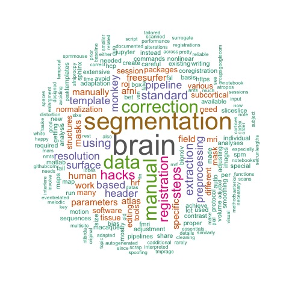

#### Q3: What are the main problems (preprocessing, analyses) that you run into and that the community needs to solve for NHP data?

ID

Response

1

Not sure of standardised pipelines

2

<no response>

3

Brain extraction (skull stripping) Surface-based analysis (generation of surface form T1, surface-based registration) Field-map based EPI distortion correction Lack of consensus on a single template space (MNI-like) Limited variety of parcellations

4

The variety of image quality is a challenge. Denoising is most of the time imperative, and non-local means is the best method we found so far.

5

- measure of the MION dose across runs and sessions - reorientation of images depending on the monkey position in the scanner - skull stripping and segmentation are time consuming , no perfert and fast methods exist - a clean surface generation tool

6

1. Standardization for brain extraction b) Standardization for dura segmentation b) Standardization of the surface registration for NHP, maybe into Freesurfer c) Design a pipeline for quality control and avoid manual correction

7

N/A

8

normalization, segmentation,

9

brain extraction; lack of the field map for distortion correction; denoising; harmonizing multi-site data etc.

10

1. Standardization for brain extraction b) Standardization for duramater segmentation c) Standardization of the surface registration for NHP, maybe into Freesurfer d) Design a pipeline for quality control and avoid manual correction

11

Preprocessing: some of the processing steps in e.g. FreeSurfer seem to depend on ‘baked-in’ knowledge of positions or morphologies of certain human brain structures, it would be fantastic if those could be generalized/made more adaptive for use in NHP brains. Analyses: availability of atlases/parcellations for surface or connectome analyses in different NHP species could be an important future goal, but this is obviously limited by the scarcity of NHP datasets other than macaques.

12

Standardized preprocessing pipelines (structural and functional) are desired for NHP.

13

<no response>

14

Need some standardised structural templates

15

NHP data its higher resolution typically and human algorithms aren’t always well adapted to this.

16

Registration to atlas takes a lot of time.

17

Preprocessing steps; hidden ‘1mm ~= 1 voxel’ assumptions in code

18

Skull-stripping.

19

motion correction can be tricky. Also excellent grey-white matter segmentation can be an issue -for flatmap generations and analyses along the cortical depth

20

The problem is more about what approach is better to show us the movements of participants in the scanner

21

One main issue with data-preprocessing of NHP data relates to the additionally large head/muscle structures of NHPs. Optimized skull-stripping and image alignment techniques are essential in this regard. Additionally, NHPs typically carry head implants (head-post and chambers) which generate large distortions on the echo-planar images.

22

common alignment space with labels, automatic parcellation into these labels based on anatomical criteria

23

<no response>

24

standardizing the normalization pipeline

25

<no response>

26

N/A

27

Time consuming manual editing; absence of atlases

28

segmentation requires lots of manual work and time, often no templates/atlases available

29

preprocessing cortical segmentation subcortical production of flat maps (each step take much longer than it should)

30

- define and implement standard parameters and option for NHP (for instance, extend regular choices like -monkey and/ or -surface_coil for a skull stripping with AFNI to many other tools).

31

N/A (rodents wise - automatic skull stripping - registration of highly distorted EPIs to templates)

32

A standardized preprocessing pipeline that works across institutes would be an extremely useful time saver. Similarly, while not always possible, a general consensus on templates would help to move the field forward.

33

In my experience, the main problems are the dynamic off-resonance effects (motion artifacts) arising due to monkey body motion (e.g. changing the position of the body in the chair) and even jaw/jaw muscle movements during or prior to reward delivery. The active training and motion-contingent trial aborts during the scanning help (at least for event-related design), but do not fully eliminate the problem. In terms of the analysis, the inability to do proper random-effect analysis across (typically two or very few) subjects, hence resorting to the individual fixed effect analysis, but at the same time being hindered and haunted by potential discrepancies between the individual subjects, especially for whole brain analyses and many ROIs (such differences, while undoubtedly present, often remain obscured by the random effect analysis in the human neuroimaging).

34

<no response>

35

> Skull stripping > Good segmentation of tissue classes, especially subcortically, in occipital lobe, near insula, etc. > Generation of surfaces and flat maps for individual NHPs

36

Brain extraction and segmentation

37

N.A.

38

39

Nothing really different from humans, but I guess that the distortion in the functional scans will be varying across labs/scanners. This is why a VERY careful co reg and then normalization will be KEY to avoid creating false variability. We would need to make SURE also to all have the exact same FOV/slice orientation (or use different orientations and see if it affects connectivity), to facilitate the final normalization. This can be done by using AC-PC or Frankfurt zero plans.

40

Brain extraction and segmentation

41

hidden defaults im conventional pre-processing tools, different data storage conventions/format across groups, agree on reference spaces in volume and surface

42

Codes for standard preprocessing steps not published

43

<no response>

44

<no response>

45

Automatic brain extraction and tissue segmentation still sub-optimal.

46

Motion correction. (also body movement artifacts) Better automated segmentation/surface generation.

47

Skull stripping for rhesus monkeys is a major issue for automatic routines such as FSL BET and AFNI 3dSkullStrip (which uses BET) because they rely on smoothing. These issues interfere with the quality of surface-based methods and alignment using FLIRT or AFNI/ANTs.

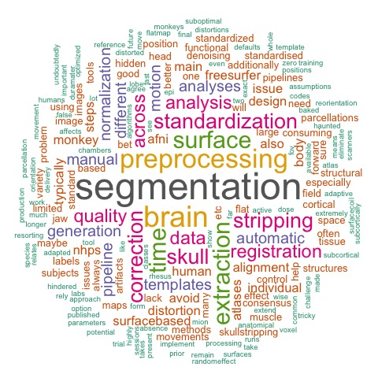

#### Q4: Do you rely primarily on volume or surface-based approaches for inter-subject registration? Is there a particular reason as to why?

[output not shown]

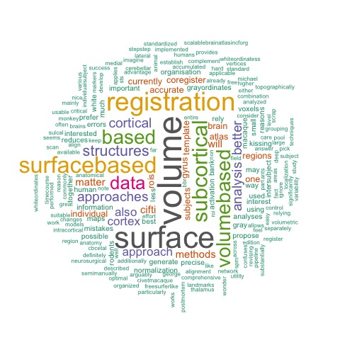

### III) Standardizing Data Collection Protocols

#### Q1: What type of scanner and head coil(s) does your work rely on? Are there any specific advantages?

ID

Response

1

Not sure yet

2

I am no longer collecting data, but we used a Siemens 3T Skyra at Mount Sinai, with some data collected on a Siemens 7T MAGNETOM. We used Hauke Kolster’s custom 4-channel or 8-channel head coils

3

Scanner 1: Siemens Prisma 3T (for macaques, baboons and others) Coils 1: single loop coil Scanner 2: Bruker Biospec 9.4T (for marmosets) Coils 2: custom-ordered single loop coil

4

Siemens Prisma 3T for acquisition. For the rest, our MR physiscist Julien Sein (also attending the workshop) will answer all questions below about acquisition.

5

Siemens prisma 3T (advantage: same as human participants) Leuven 8 channels coils (ok for females but difficult for males due to head muscles; keeping the same position of the coils across sessions is an issue and can deeply affect the SNR ; for auditory protocols difficult to spatially arrange the coils with earplugs)

6

1. We work with a 3T Philips Achieva scan with 4 kinds of coil, the use depends of the sequence a) 8-channel monkey head coil b) 32-channel SENSE Head coil for human c) 16-channel Pediatric SENSE Head/Spine coil d) 6-channel SENSE Flex M coil

7

N/A

8

N.A.

9

3.0 Tesla Siemens Tim Trio scanner with an 8-channel surface coil adapted for monkey head scanning, 3.0 Tesla Siemen Tim Trio scanner with a 15-channel knee coil adapted for monkey head scanning

10

1. We work with a 3T Philips Achieva scan with 4 kinds of coils, the use depends on the sequence a) 8-channel monkey head coil b) 32-channel SENSE Head coil for human c) 16-channel Pediatric SENSE Head/Spine coil d) 6-channel SENSE Flex M coil

11

N/A

12

N/A

13

<no response>

14

Scanner type: 3T horizontal bore scanner (Siemens Trio) Head coil: Surface coil

15

Macaques 7T Terra Plus with AC84 Mk2 gradient coil with 8ch transmit, 24 ch receive. Allows for B1+ shimming and highly accelerated acquisitions which are important for reducing geometric distortion and high temporal coverage. Marmosets 9.4T 8ch Rx with custom 20cm ID gradient coil

16

Siemens 7T scanner and multi-array coil made in-house. Advantages are SNR, high spatial resolution.

17

Bruker 9,4T / custom 8ch head array

18

Standard Siemans 3T human scanner. A surface coil, which increases signal compared to knee coil. Ideally there would be a purchasable multi-channel head-coil for NHP use.

19

3T Siemens PrismaFit We make custom-built coils in the lab. Either 8 channel external coils, or implanted phased array coils (up to 10 channels). Especially the latter yields excellent SNR (e.g. 0.6 mm resolution images covering the entire brain at 3T).

20

siemens

21

4T or 7T, with Hauke Kolster 4-8 channel coils. Hauke Kolster coils are flexible allowing placement changes for individual animals with different head implants.

22

Siemens Prisma, 4 or 8 channel surface coils from Kolster-Windmiller for fMRI, Siemens 1 channel loop for anatomical

23

4Channel coil from Windmiller Kolster

24

Bruker scanners (4.7 T, 7 T) with custom-built head coils

25

<no response>

26

9.4 tesla Bruker Scanner and 3 tesla Philips Scanner (8 channel head coil)

27

3T Siemens Tim Trio 3T Siemens Prisma 11.7T Bruker Biospec

28

3T Siemens Tim Trio, 3T Prisma, 11.7T Bruker Biospec

29

Siemens 3T Prisma awake functional : ad hoc 2x4-channel coils (Leuven style) : excellent for occipito-parieto-prefrontal / sub-optimal for orbitofrontal & subcortical anesthetized functional / anatomical or dMRI: 2 L11 coils + 1 L7 coil

30

3T horizontal Siemens scanner with 1Tx-1Rx or 1Tx-8Rx head coil. 7T horizontal Siemens scanner. (11.7T coming next…)

31

Burker 7T pharmascan. Bruker standard 4 element coil reduces matrix size and reduces EPI artefacts close to auditory canals. (*Please note this applies to rodents - feel free to scrap this from the answer pool if not applicable*)

32

Tim Trio 3T with a custom built 8-channel transmit and receive coil system. Advantages are being able to place the coils with different placements of head-posts and chambers. Disadvantage are inhomogeneities across the brain and different placements of the coils across sessions.

33

Previously Bruker 4.7T vertical (Caltech) with Bruker birdcage volume coil or quadrature coils (Bruker/Helmut Merkle), with adjustable matching/tuning. Advantages are the higher field strength and the more natural vertical sitting position of the animal (but there are also many disadvantages). Currently 3T Siemens Prisma with Hauke Kolster’s coils (https://www.wkscientific.com/): 1) Single channel Rx coil for the volume and surface anatomy (with the scanner bore Tx and pre-scan normalization, enabling fairly homogeneous RF coverage) 2) Single channel Tx-Rx for vessel localization and some diagnostic scans 3) 4-ch and 8 ch Rx + single channel Tx for fMRI The advantage of these lightweight and adjustable coils is flexible placement of coil elements around the head and headpost / chamber implants, and adjustable tuning/matching allowing for the optimization of the coil to individual subjects.

34

3T Prisma, 2Loops 11cm or 16ch Pediatric coil, or 1Tx8Rx for fMRI 2loops better for image homogeneity, signal on small animals 1Tx8Rx good for fMRI on cortex

35

Bruker Vertical 4.7 T with various coils (8-channel RAPID, house-made 1,4, and 5 channel coils). Siemens Prisma horizontal 3T scanner. Single Channel knee coil and multi-channel coil in future.

36

Macaque: 24-ch coil multi-array RF coil Marmoset:16-ch multi-array RF coil with 2-ch multi-channel Tx coils Both on a 3T Siemens Prisma MRI scanner

37

I am considering about this topic.

38

10.5 T Siemens. Custom head coils

39

Until 2018, Bruker 7T and 4.7T (vertical), with custom-made quadrature and in a few cases phased-array fixed on individual 3D-printed helmets developed back then by David Balla and Helmut Merkel at MPI-BC. Soon, 3T Prisma. I am interested in using implanted coils after seeing the highly reproducible results of Wim Vanduffel.

40

Macaque: 24-ch coil multi-array RF coil, Marmoset:16-ch multi-array RF coil with 2-ch multi-channel Tx coils on 3T Siemens Prisma MRI scanner

41

Siemens

42

N/A

43

<no response>

44

<no response>

45

4.7 T actively shielded vertical MRI scanner (Bruker Biospec 47/60 VAS) equipped with an actively shielded gradient system (Bruker GA-38S) of 38 cm innerbore diameter (Bruker BioSpin, Ettlingen, Germany); 8-channel receiving surface phased-array coil

46

Philips Achieva 3T Custom-built 8-channel head-coil (KU Leuven / MGH design) Advantage: Coils are mounted on the chair with flexible arms for optimized positioning. Disadvantage: We need an extensive chain of connections to hook up the coils to the scanner (coils - preamp - adapter plus - research connector unit - scanner) which can make debugging issues difficult.

47

Siemens Allegra 3T with custom designed coil.

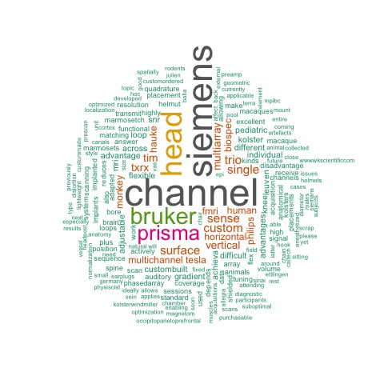

#### Q2: What image sequence types do you obtain in all studies? (e.g., T1W, T2W, dMRI, fMRI, field map); for each modality, what spatial resolution and (if used) multi-band factor?

ID

Response

1

T1W, often T2W for hippocampal subfields

2

T1w 0.5mm^3, T2w 0.5mm^3, dMRI (with reverse polarity sequence) 1mm^3, resting-state fMRI (1.5mm^3 - with reverse polarity sequence). Quantitative T1 0.5mm^3 Multiband = 2 & multi-echo for fMRI

3

T1w, T2w, fMRI, DTI, MT, and field map images are routinely obtained

4

N/A

5

T1/ T2 0.4mm fMRI 1.25 mm multiband 2 (not sure)

6

T1W, T2W, T2-FLAIR = 0.5 mm3 dMRI and field map =1.3 mm3

7

N/A

8

T1W, T2W, dMRI

9

T1w, T2w, field map, resting-state fMRI, movie fMRI, task fMRI 0.5mm isotropic for T1w and T2w; 1.5mm isotropic for fMRI data.

10

T1W, T2W, T2-FLAIR = 0.5 mm3 dMRI and field map =1.3 mm3

11

N/A

12

N/A

13

<no response>

14

Resting-state: Voxel resolution: 1.9 x 1.9 x 1.8mm Diffusion-weighted (DTI): Voxel resolution: 1.8 x 1.8 x 2.5mm Structural: T1: Voxel resolution: 0.5 x 0.5 x 1.0mm T2: Voxel resolution: 0.5 x 0.5 x 1.0mm Magnetic Resonance Spectroscopy: Voxel resolution: 10 x 10 x 10mm

15

T1W, fMRI, field map, B1+ map, dMRI

16

T1W, fMR, field map, dMRI.

17

PD-T2w fMRI/field maps no multiband spatial resolution 0.25mm-0.4mm

18

T1, dMRI, fMRI, field-map. ~2mm for dMRI and fMRI. ~.5 mm for T1.

19

All of the above. Mostly multiband (factor 2-3)

20

T1W, T2W, dMRI (DTI), fMRI, field map

21

I typically acquire structural data at 0.5 isotropic for T1, T2and 1mm DWI and 1mm isotropic for EPI.

22

T1, EPI

23

T1 MPRAGE fMRI dMRI fieldmap gre3d

24

GE-EPI (1x1x2 mm whole brain), fieldmap, RARE, FLASH, MDEFT, no multi-band, but some 2x GRAPPA accelerated parallel imaging (1x1x1 mm)

25

<no response>

26

T1 weighted, T2 weighted, diffusion MRI, field Map, Magnetization Transfer

27

most often T1W, T2W, in some cases dMRI. Spatial resolution varying from 75µm isotropic up to 500µm isotropic (ex-vivo scanning for >12h).

28

mostly T2W, TW1, sometimes dMRI spatial resolution depending on specimen size between 100µm and 550µm isotropic (scanning max ~12h)

29

T1W, T2W, dMRI, fMRI field maps occasionally

30

sturcutral = T1 ; MPRAGE 0.80 mm isotropic functional = T2* ; gradient-EPI 1.00 mm isotropic field map

31

T2W RARE, dMRI, FMRI - no0 file map usually No multi-ban (at the moment) Resolution around 200 x 200 x 600 um (*Please note this applies to rodents - feel free to scrap this from the answer pool if not applicable*)

32

We collect: T1w .5 isotropic T2w (SPACE) .5 isotropic DSI EPIs 1.6x1.6x2.0 with contrast agent forward/reverse Spin Echo EPIs for field maps 1.6x1.6x2.0

33

T1W (MPRAGE). 0.5 iso T2W (RARE), 0.25 x 0.25 x 1 mm for in-plane anatomy and electrode localization fMRI (GE EPI) (1.2 iso); MB in development, targeting 1x1x1 mm and TR 1 s GRE for RF sensitivity maps

34

T1w MPRAGE: 0.4mm iso, T2w: SPACE 0.4mm iso, DWI: SE-EPI, 1mm iso, MB=2 if coil allows fMRI: 1.5mm, MB=2 if coil allows

35

T1W (typically 0.5mm isotropic MDEFT) for daily anatomical. Field Map. Place correction scan. fMRI (typically a 1.5 mm isotropic EPI) sometimes a T2W RARE scan.

36

Macaque: T1w: 0.5mm T2w: 0.5mm dMRI: 0.9mm (MBF=2, iPAT=2) fMRI:1.25mm (MBF=5) Spin-echo type B0 Field Map Marmoset: T1w: 0.36mm T2w: 0.36mm dMRI:0.7-0.8mm (MBF=2, iPAT=2) fMRI:0.8-1.0mm (MBF=2) Spin-echo type B0 Field Map

37

N.A.

38

T1W 0.5 mm isotropic T2W 0.5 mm isotropic fMRI 0.75 mm isotropic, MB2 B1 1 mm isotropic B0 1 mm isotropic

39

- GE-EPI, 1x1 mm2 in-plane res., TR/TE 200/20 ms, 20 to 25 axial slices with quadrature coil. - GRAPPA-accelarated parallel imaging, 0.85x0.85 mm2, TR 1 sec, 18 to 20 axial slices with helmet. - T1W MDEFT - T2W RARE

40

Macaque: T1w: 0.5mm T2w: 0.5mm dMRI: 0.9mm (MBF=2, iPAT=2) fMRI:1.25mm (MBF=5) Spin-echo type B0 Field Map Marmoset: T1w: 0.36mm T2w: 0.36mm dMRI:0.7-0.8mm (MBF=2, iPAT=2) fMRI:0.8-1.0mm (MBF=2) Spin-echo type B0 Field Map

41

T1w, dMRI, MPM, 1.5-2 mm

42

N/A

43

<no response>

44

FMRI

45

T1W and T2W (0.8 mm isotropic)

46

T1W - 0.6 mm iso T2W - 0.6 mm iso DWI - 1.0 mm iso fMRI - 1.25 mm iso, SENSE factor 2, no multi-band B0 - 1.25 mm iso

47

T1W, 0.6mm^3 fMRI, 1.6mm^3, TE=0.03, TR=2s, Flip Angle=79 degree, (sequence: ep2d_bold_64_HF)

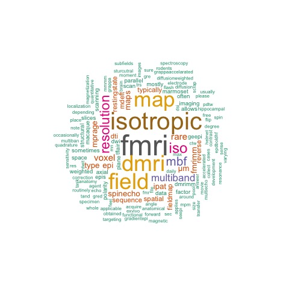

#### Q3: Are you using MION or other iron-based contrast agents? If so, what specific agent and dose?

ID

Response

1

Haven’t acquired NHP data myself

2

No

3

NO

4

N/A

5

MION , from 11mg/kg to 8-9 during a continuous period of scanning (one session per day) Then we use at the end Desferal to remove the accumulated iron.

6

3. We don’t use contrast agents

7

N/A

8

N.A.

9

MION, 10 mg/kg

10

N/A

11

N/A

12

N/A

13

<no response>

14

None

15

No

16

Following the method of Landi and Freiwald 2017, Sliwa and Freiwald 2017, a MRI contrast agent Molday ION (BioPAL, Inc) was injected at iron doses of 8 mg/kg into femoral vein of macaque monkey before scanning. 1. S. M. Landi, W. A. Freiwald, Two areas for familiar face recognition in the primate brain. Science. 357, 591-595 (2017). 2. J. Sliwa, W. A. Freiwald, A dedicated network for social interaction processing in the primate brain. Science. 356, 745-749 (2017).

17

No

18

No.

19

Always for functional imaging. Currently we use Molday (~ 10mg/kg)

20

iDK

21

No MION and no contrast agents. At least at 4T (BOLD) 1 single movie run 5 minutes (30-sec movie segments 5 repeats) can provide FDR-corrected significant activation maps with greater than 3% signal change from the mean.

22

currently not, prior Feraheme or Molday ION, CLIOH, 8-10 mg/kg

23

No

24

only BOLD at the moment

25

<no response>

26

N/A

27

We have experimented with gadolinium and fluorinert to improve tissue contrast (but the person who knows is our MR physicist, Mathieu Santin from ICM)

28

gadolinium and fluorinert have been tested –> Mathieu Santin from ICM Paris is the expert

29

Molday Ion 10mg/kg

30

- iron-based contrast agent (SINEREM, MION, FERAHEME) at 10 mg/kg in IV - pure BOLD signal

31

yes for fucntional imaging - Molday Ion, 2.5 (5 ul/g i.v.) (*Please note this applies to rodents - feel free to scrap this from the answer pool if not applicable*)

32

We are using MION (Molday 10-12mg/kg).

33

We mainly used BOLD for fMRI so far, and some pilot microstimulation-fMRI sedated scans with MION (Rienso ferumoxytol 30 mg/ml). We use Gadolinium (Magnevist) for injection localizations (1:200 Gd to PBS).

34

yes MION for fMRI on awake macaques. Gd for perfusion MRI on some projects

35

house-made MION, 12-18 mg/Kg, to achieve a 50-60% signal reduction relative to EPI signal before MION.

36

MION

37

N.A.

38

None

39

Not yet but will very likely do so at 3T.

40

MION

41

no

42

N/A

43

<no response>

44

<no response>

45

no

46

Not at the moment. BOLD works reasonably well for us, but we do consider MION for certain studies.

47

N/A

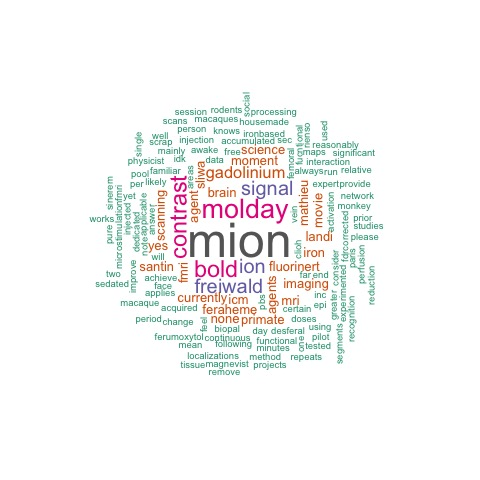

#### Q4: If you use anesthesia, what specific type and levels do you use?

ID

Response

1

Haven’t acquired NHP data myself

2

isoflurane 1.0-1.6%

3

Isoflurane (in intubated and mechanically ventilated animals), concentrations vary (1-2%) Propofol, infusion rates vary depending on age, weight, physiological monitoring,

4

N/A

5

We use Domitor to do the IV injection of MION , then we remove the anesthesic with a product called antisedan juste before the scanning session

6

Ketamine-xylazine (7/0.6 mg/kg)

7

N/A

8

Propofol

9

Initial dose: atropine (0.05 mg/kg IM), dexdomitor (0.02 mg/kg IM) and ketamine (8 mg/kg IM) for intubation; maintaining dose: 0.75% isoflurane anesthesia

10

Ketamine-xylazine (7/0.6 mg/kg)

11

N/A

12

N/A

13

<no response>

14

Atropine was applied via subcutaneous injection 20min before anesthesia (dosage = body weight * 0.05mg/kg). ZoletilTM 50# was used via subcutaneous injection (dosage = body weight * 0.1ml/kg) After the monkeys were head-fixed on the Stereotaxic, 0.3ml ZoletilTM 50# was injected.

15

Isoflurane at 1%.

16

Animals were anesthetized with ketamine hydrochloride (10 mg/kg) and maintained with propofol (5 mg/kg/hr, induction 5mg/kg) or sufentanil (2-4 µg/kg/hr, induction 3 µg/kg) supplemented with up to 1% isoflurane.

17

Isoflurane 1-3% in 0.3-0.5l/min O2

18

Ketamine for intubation and isoflurane, 1-2%.

19

barely ever. If we perform anesthesia it is either isoflurane or ketamine/xylazine

20

<no response>

21

I do not recommend the use of anesthesia for functional scans EPI sequences. It is much easier to do awake-fMRI. It is very difficult to keep the animal under anesthesia under 1% isoflurane. The anesthesia cocktail with muscle paralysis was very effective but remains controversial given the potential masking of nociceptive signals.

22

Isoflurane, <1% for resting state, 1.5% for anatomy

23

Isoflurane (around 1%)

24

Anesthesia used - remifentanil for functional imaging, isoflurane just for structural scans

25

<no response>

26

N/A

27

no need

28

n.a. (all post mortem)

29

isofurane 1-2%

30

- Sevoflurane (moderate sedation: 2% ; deep sedation 4% - inhaled volume) - Propofol (moderate sedation: 3.7 to 4.0 μg/ml ; deep sedation 5.6 to 7.2 μg/ml - IV, based on the Paedfusor pharmacokinetic model) - Ketamine & Dexmedetomodine (IM injection, then IV infusion 5 to 16 mg/kg/h to maintain)

31

Halothane 0.7% (intubation), isoflurane 0.8% intubation (*Please note this applies to rodents - feel free to scrap this from the answer pool if not applicable*)

32

For about half our scans we use anesthesia. We induce with 5mg/kg Ketamine and .15mg/kg Dexdomitor. We then maintain the anesthesia on 0.75% isoflurane during functional imaging.

33

For full anesthesia, mainly isoflurane 1-1.5% (for the resting state fMRI) or propofol (for the anatomical scans with MRI-compatible stereotax). For sedated scans in the MRI chair, Ketamin/Dexdomitor or only Dexdomitor (in particular when the animal is trained to enter the MRI horizontal chair).

34

<no response>

35

generally none. Sometimes we use light sedation: Vallium (i.m. only or equal parts i.m. and i.v.) or Vallium + Ketamine. Isoflourane for high resolution anatomical scans

36

Dexmedetmidine 4-6microgram/kg/hr + 0.5-0.6% isoflurane in macaque and marmoset

37

N.A.

38

Isoflurane, 1% for anesthetized scans

39

remifentanil (1-3 µg/kg/min, analgesic and anesthetic) mivacurium chloride (5-7 mg/kg/h, muscle relaxant)

40

Dexmedetmidine 4-6microgram/kg/hr + 0.5-0.6% isoflurane in macaque and marmoset

41

42

N/A

43

<no response>

44

<no response>

45

Awake imaging.

46

Generally, we scan awake. For ‘arrival’ or ‘localization’ scans in non-MRI dedicated animals we use a mixture of Ketamine (0.07 ml/kg, at 100 mg/ml) and Medetomidine (0.1 ml/kg, at 1 mg/ml)

47

Isoflurane (0.5-2.0%)

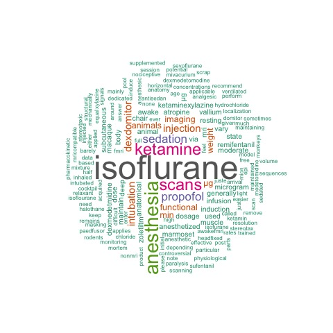

#### Q5: What protocols have you applied to do awake imaging (e.g., Do you obtain eye-tracking in the scanner? What physiologic measures?)?

ID

Response

1

Haven’t acquired NHP data myself

2

Eye tracking

3

Physiological measures obtained: heart and respiratory rates, rectal temperature, capnography, pulse oximetry

4

N/A

5

We control the triggers of the scanner depending on the monkey behavior (monitored by a camera inside the scanner but without eye track) ; via a home made matlab script (Regis Trapeau) If the monkey move the acquisitions stop and no reward is delivered. All these steps are indicated to the monkey via a screen. The protocol is an auditory passive (just stay still) listening task 4 categories of sounds are used: macaque voc ; human voc ; marmoset voc and environmental sounds Stimuli are delivered in an event related paradigm ( but 3 repetition per sound) during silent time frame (clutered sparse acquisition)

6

We do not work with awake imaging, yet.

7

N/A

8

N.A.

9

naturalistic viewing movie fMRI without eye-tracking at the current stage but would prefer with eye-tracking recording.

10

N/A

11

N/A

12

N/A

13

<no response>

14

not awake

15

Eyetracking, heart rate, respiration, temperature

16

Currently we record the eye-movement. Would be better to record the physiological factors especially heart rate, respiration and pupil size. Cardoso MMB, Lima B, Sirotin YB, Das A (2019) Task-related hemodynamic responses are modulated by reward and task engagement. PLOS Biology 17:e3000080.

17

N/A

18

Only ‘resting’ MRI – heart-rate and temperature.

19

always eye-tracking (position and pupil). We also control hand positions. Extensive training fo the animals prior fMRI acquisition is KEY.

20

<no response>

21

Depending on the animal willingness to work for eye-calibration I do obtain eye-tracking signals. But it is not always a possibility.

22

Eye-tracking

23

Eye monitoring has been used using MRC camera and python based software provided by Olivier Joly

24

only did limited away image, where pulse oximetry and eye-tracking was recorded during imaging.

25

<no response>

26

Arrington Research Eye Tracker is used. Further the physiological measures of heart rate and breathing is taken care off during data acquisition.

27

no awake imaging

28

–

29

too many to describe eye tracking data recorded in awake protocols

30

- eye tracking - HD camera - fixation rate for a specific window - (…)

31

work in progress

32

We currently only collect eye-tracking during awake imaging.

33

Eye-tracking, image-based jaw/body motion tracking with movement contingent trial aborts for the time-resolved event-related designs, where the trial might be structured like a typical delay-response ephys task (but with longer intervals to account for the BOLD HRF), with fixation, visual cue, memory delay, saccade or hand movement response, and after some additional delay - large liquid reward. If monkey is aborting the proper eye/hand fixation or moves his jaw or body noticeably, the trial is aborted and no reward is delivered. The monkey is allowed of course to move during the reward period and the inter-trial interval. Currently, we are developing respiration (easy) and heart rate (ECG, more difficult) monitoring during the awake imaging.

34

<no response>

35

eye-tracking reward face-oriented camera pupil diameter end tidal CO2 collection possible during sedated scans

36

Eye-tracking

37

N.A.

38

Eye Tracking, movement,

39

Natural scene movie clips, with eye tracking Taste Vagus nerve stim Intracerebral stim Visual flicker Resting

40

Eye-tracking

41

42

N/A

43

<no response>

44

<no response>

45

Eye-tracking data for fMRI.

46

We routinely use: - Eye-tracking - Tracking of hand position & 2 levers with optic fibers (4 sets in total)

47

N/A

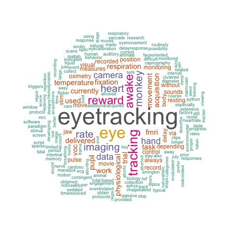

#### Q6: What protocols are you using to optimize various acquisition parameters? Or rather, what are the tools and parameters you use to assess the quality of your acquisition?

ID

Response

1

Haven’t acquired NHP data myself

2

We had a lot of trouble with non-linear distortion through the field caused by body motion in our early awake scans. We visually inspected the data for these artifacts.

3

assessment of tSNR (for fMRI data)

4

N/A

5

na

6

We use MRIQC

7

MRIQC

8

I am pondering about this topic for my data scan.

9

N/A

10

We use MRIQC

11

N/A

12

N/A

13

<no response>

14

Optimization of the magnetic field prior to data acquisition: Manual shimming

15

Real time motion and image stability verification on both scanners.

16

<no response>

17

<no response>

18

None. Mostly relying on the work of other groups and co-opting protocols.

19

tSNR measurements are typically very useful. We also control teh images online. Motion is usually a major culprit. Hence reducing motion is something we really focus on.

20

3D T1 volume MPRAGE T2 PROPELLER Axial T2 FLAIR Susceptibility Weighted Images (SWI) T2*-weighted EPI (Resting-State fMRI) and Field Maps Diffusion Tensor Image (DTI)

21

I used BOLD modulation and the FFT of each voxel for block-design to asses the quality of the data during acquisition. Essentially a 5 min movie run.

22

Q&A package from MGH, uncombined sequences, tSNR

23

<no response>

24

online assessment of ghosting artifacts and warping, offline calculation of tSNR maps

25

<no response>

26

Standard protocols

27

28

–

29

global and local SNR measures head movement regressors eye movement patterns

30

<no response>

31

Nothing fancy- standard measurements such as SNR, tSNR. (*Please note this applies to rodents - feel free to scrap this from the answer pool if not applicable*)

32

<no response>

33

During data acquisition: The noise level and any RF frequency (zipper) artifacts are tested by turning off the RF amplitude (via software sequence parameters) and acquiring several volumes of background noise EPI prior to actual EPI acquisition. For multichannel coils, an uncombined sequence is acquired to check each coil element (channel) separately. For the awake T1W anatomical scans (e.g. MPRAGE), the phase encoding direction (L-R vs. A-P, or H-F) can be optimized to minimize the eye/jaw/body motion artifacts and the interference from Gd filled chambers for the chamber localization scans. Volume-selective 3Dvshimming is performed iteratively using advanced adjustments while the monkey is not moving, and then optimized further using manual interactive adjustment of individual shims, to minimize the width of the tuning curve and maximize T2*. Offline: The fMRI EPI series are subjected to QA pipeline assessing spatial and temporal SNR and temporal stability, via NeuroElf and custom QA MATLAB code. The outlier volumes are detected from the EPI stability timecourse and modeled with confound predictors (and excluded from event-related averages).

34

SNR measurement for each session and look at noise correlation of coils.

35

Collect a Place scan to correct for field inhomogeneities. Confirm monkey did not move during Place scan. Assess % signal drop caused by MION. measure SNR after MION by comparing mean EPI signal in brain with st.dev. of signal with transmit coil off. Assess tSNR after deconvolve. F-stat of deconvolve model or peak F-stat in volume.

36

NHP HCP protocols using species-specific spatial resolution based on cortical thickness. Temporal resolution of fMRI, comparable with human high-quality data like HCP

37

N.A.

38

tSNR, cSNR, distortions, beta maps

39

We remove scans with major motion artifact, rather than correcting them. we check each scan for spikes, ghost artifact.

40

NHP HCP protocols using species-specific spatial resolution based on cortical thickness. Temporal resolution of fMRI, comparable with human high-quality data like HCP

41

42

N/A

43

<no response>

44

<no response>

45

SNR and CNR

46

SNR, tSNR

47

Automatic anatomical QA based on contrast between foreground/background/WM/GM/CSF.

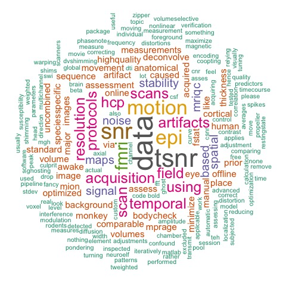

#### Q7: What acquisition standards do you feel are required for surface-based or volume based processing and registration?

ID

Response

1

Haven’t acquired NHP data myself

2

<no response>

3

<no response>

4

N/A

5

na

6

1. Voxel size: 0.5 mm3 or less b) Get 3 or more T1W images for improve SNR c) Try to keep the same position into scanner (using the primate chair) d) Get a sequence for dura segmentation (for example T2-FLAIR) e) Control the level of hydratation of the animal during the acquisition

7

Ways to know with pilot scanning if the field homogeneity is good enough for processing and registration.

8

N.A.

9

The baseline (before any implantation) scan with multiple T1w and T2w as the basis.

10

We feel the next are required: a) Voxel size: 0.5 mm3 or less b) Get 3 or more T1W images for improve SNR c) Try to keep the same position into scanner (using the primate chair) d) Get a sequence for duramater segmentation (for example T2-FLAIR) e) Control the level of hydratation of the animal during the acquisition

11

N/A

12

A high quality and high resolution isotropic T1 sequence is required.

13

<no response>

14

N/A

15

<no response>

16

T1W is enough. High resolution and multiple scans helps. Multiple scans can be averaged to remove noise, so that it can be registered to the atlas well. The challenge is an optimal algorithm (pipeline) for a good non-linear registration.

17

<no response>

18

High-quality T1.

19

1mm isotropic resolution is the bare minimum,

20

<no response>

21

I sometimes do whole-brain or partial-brian acquisitions. For each type of scan, I acquire an individual T1 volume.

22

<no response>

23

<no response>

24

for volume-based processing, whole-brain coverage with spatial resolution rivaling that of a small FOV image intended primarily on obtaining posterior brain coverage

25

<no response>

26

N/A

27

isotropic voxels

28

isotropic resolution

29

<no response>

30

<no response>

31

N/A

32

<no response>

33

N/A

34

<no response>

35

Daily T1W anatomical scan. Higher resolution T1W scan helpful (especially if collected under anesthesia).

36

High resolution, high homogeneity, high quality images for structural MRI High resolution, high temporal resolution images of fMRI High resolution, high angular resolution, high b-value diffusion weighting of dMRI

37

N.A.

38

Depends on the scientific question and the tradeoffs one is willing to make. Ideally 1 mm isotropic or higher.

39

- Exact same landmarks to align the slice and FOV of the acquisition (e.g., AC-PQ. - Careful, if needed semi-manual, coreg, then normalization onto a standard brain with its complete ROI map.

40

High resolution, high homogeneity, high quality images for structural MRI High resolution, high temporal resolution images of fMRI High resolution, high angular resolution, high b-value diffusion weighting of dMRI

41

42

N/A

43

<no response>

44

<no response>

45

resolution < 1 mm isotropic

46

Good GM/WM contrast.

47

Isometric voxel size is required for surface based processing, but might be less critical for volume-based processing

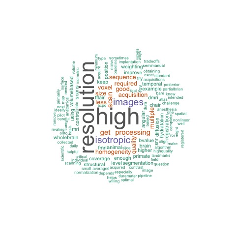

#### Q8: What do you use for distortion correction and acquisition for Mion vs BOLD sequences?

ID

Response

1

Haven’t acquired NHP data myself

2

We just did BOLD-imaging. We used multi-echo-multi-band, with multi-echo ICA de-noising. For distortion correction, we used TOP-UP for distortion correction (having acquired some volumes with the opposite phase-encoding direction).

3

<no response>

4

N/A

5

na

6

We do not use contrast agents

7

N4 (ants), topup

8

N.A.

9

FSL TOPUP for BOLD sequences.

10

N/A

11

N/A

12

N/A

13

<no response>

14

N/A

15

N/A

16

EPI distortion correction with two opposite encoding phase.

17

<no response>

18

I’m experimenting with top-up. It appears to be taking a step in the right direction…

19

W use as short TEs as possible (depends on scanner specs).

20

<no response>

21

I don’t think MION is required for the reliable acquisition of NHP imaging data. Thus, I refrain from using MION.

22

<no response>

23

Reconstruction tools provided by Hauke Kolster, or Mark Chiew (WIN, Oxford)

24

Using only BOLD sequences - unwarping by fieldmap or point-spread-correction of EPI distortion map

25

<no response>

26

Standard Old Normalization and two way brain masking and re-alignment

27

28

–

29

jip and FSL

30

<no response>

31

Just 12 dof registration - MION are much less distorted so no correction is required. (*Please note this applies to rodents - feel free to scrap this from the answer pool if not applicable*)

32

We are currently using a set of forward and reverse phase direction Spin Echo images for distortion correction. We collect a set both before and after MION injection in case MION has an effect on the distortion.

33

BOLD only with Fieldmap Plan to use TopUp https://fsl.fmrib.ox.ac.uk/fsl/fslwiki/topup/Faq with FSL

34

same sequence

35

Place scan to correct for field inhomogeneities. TE ~17 ms for BOLD and 13 ms for MION.

36

Spin-echo type B0 fieldmapping

37

N.A.

38

FSL topup

39

n/a

40

Spin-echo type B0 fieldmapping

41

field map, topup

42

N/A

43

<no response>

44

<no response>

45

<no response>

46

We currently register to an unwarped reference (Bo-based) but also acquire TOPUP scans and fieldmaps with every session.

47

ANTs N4 B0 distortion correction

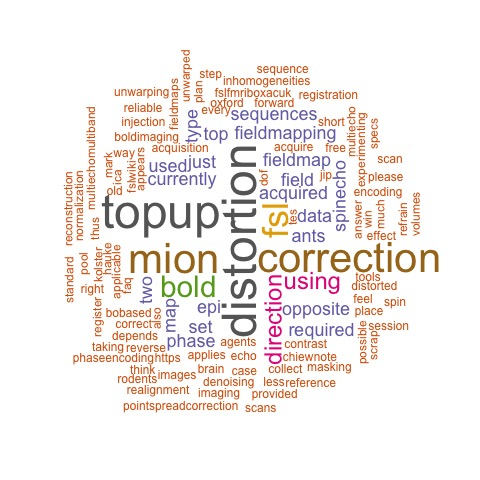

#### Q9: What would you like to see as a ‘standard’ for acquisition sequences across community and PRIME contributors?

ID

Response

1

T1W, T2W, DTI, localizer fMRI

2

<no response>

3

<no response>

4

N/A

5

na

6

1. FOV size, flip angle, voxel size for T1W/T2W/dMRI/fMRI b) kinds of coils recommended c) sequences for improve the brain extraction. d) For T1W and T2W : Minimum number of images to improve SNR e) For dMRI: b-values, numbers of B0 images, minimum number of directions and echo spacing value.

7

A standard that compares and expands on human and primate scanners, different coils, positions (supine vs standing), scanner strengths and vendors (Philips vs Siemens).

8

Flexibility

9

<no response>

10

We would like the next: a) FOV size, flip angle, voxel size for T1W/T2W/dMRI/fMRI b) kinds of coils recommended c) sequences for improve the brain extraction. d) For T1W and T2W : Minimum number of images to improve SNR e) For dMRI: b-values, numbers of B0 images, minimum number of directions and echo spacing value.

11

N/A

12

T1, T2, DWI, resting-state fMRI

13

<no response>

14

N/A

15

FLAWS or some kind of sequence which can give grey matter bright and white matter dark and vice versa. Would likely help registration. T1 weighted EPIs to register to T1 weighted anatomicals.

16

A standard acquisition can certainly make the analysis easier. The registration between structures takes a lot of time. - Better decide one image modality: T1W or T2W. - Making the center of the brain approximately the same will work well with an automatic analysis pipeline. - Head orientation can be adjusted, but should be indicated in documentation. - Multiple scan sessions is recommended, so that one can create a high-quality average image. - There is a big difference between male and female monkey brains. Choose 1 sex if possible. The functional images - EPI distortion should be corrected, for example with scanning both phase-encoding directions. It takes very little time to scan an extra image for correction purpose. - In case the registration fails, the center of the functional image should be the same with the structural image during acquisition.

17

<no response>

18

No strong opinion, other than there should be a standard.

19

I think we have to discuss this at the mtg. We are heavily investing in implanted PA coils coils which is truly transformative compared to standard imaging. This is probably not feasible at this moment for most groups.

20

more about rsfMRI

21

DWI, and naturalistic-free viewing (awake-fMRI). I believe is very important, if the compilation of a large number of primates is to be taken as an overall result to keep a good eye on data coming from chamber implanted monkeys as these might contain large distortions and result in false-positive outcomes if not deal-with correctly.

22

common parameters for EPI imaging, probably not multiband

23

<no response>

24

a standardized slice thickness would be helpful, for instance, if everyone worked to constrain slice thickness along the z-stack to a maximum of 1-2 mm would ensure that we obtain higher-resolution intra-laminar data

25

<no response>

26

N/A

27

28

29

This is a very broad question, but for sure MION acquisitions should be prioritized both in awake and anesthetized designs + eye tracking signals + systematic T1W, T2W, fMRI

30

<no response>

31

N/A

32

I think creating a standard for this would be difficult and studies may require different acquisition sequences, however, I would like to see whole brain T1w images at a max of .5 isotropic. This will help greatly in comparing across subjects and studies regardless of other acquisition differences.

33

For EPI, 1 mm isotropic voxel with TR 1 s, 36 slices.

34

<no response>

35

<no response>

36

Investigators should aim for as high-quality, high resolution images as possible, but these depend on the availability of sequences (e.g. multi-band EPI sequence) and multi-array coils used on or with the MRI scanner as is done in HCP-style projects.

37

N.A.

38

<no response>

39

- standard brain orientation for an easier registration to a common anatomical/ROI map - same ROI map / standard template with map across labs

40

Investigators should aim for as high-quality, high resolution images as possible, but these depend on the availability of sequences (e.g. multi-band EPI sequence) and multi-array coils used on or with the MRI scanner as is done in HCP-style projects.

41

42

N/A

43

<no response>

44

<no response>

45

T1W and T2W for structural MRI (rather than T1W only)

46

Not a strong opinion about this, but some level of standardization might definitely be nice.

47

N/A

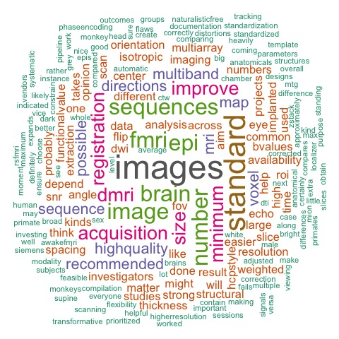

#### Q10: If you would like to provide any additional suggestions or information, please do so here.

ID

Response

1

Excited to discuss NHP imaging!

2

<no response>

3

What is an appropriate HRF for macaques and other NHP species? Should we have a ‘canonical’ awake macaque HRF? How does anesthesia affect the HRF?

4

N/A

5

na

6

<no response>

7

N/A

8

I will send you an email about this later.

9

<no response>

10

<no response>

11

N/A

12

N/A

13

<no response>

14

N/A

15

<no response>

16

<no response>

17

<no response>

18

<no response>

19

<no response>

20

I would like to see more about data acquisition

21

In general, use innovative movie (or complex music/sound) paradigms with increasing natural complexity to capture the propagation of network information across a large number of regions will be a very good and simple addition to standardized paradigms. Avoid the used of standard-trial by trail type paradigms as these will complicate the compilation of a large number of animals with different performances and task strategies etc. Performance in the scanner becomes variable and tedious for monkeys and they tend to perform way fewer trials as compared to when performing the task on a neurophysiological or behavioral booth.

22

It would be helpful to know if anyone has a fieldmap sequence that can be acquired with the same spatial resolution as the EPI sequences.

23

<no response>

24

let’s see what comes …

25

<no response>

26

N/A

27

I suggest storing shared data in Zenodo, as individual files (instead of as a single large .zip)

28

access to single datasets would be nice (like using zenodo (or figshare) I prefer a (BIDSified) naming scheme where the species name is still somehow visible. You provide mostly crab-eating and rhesus macaques – but even in these cases, I like better the naming you provide in utrecht site than in others)

29

<no response>

30

<no response>

31

N/A

32

<no response>

33

N/A

34

<no response>

35

<no response>

36

<no response>

37

N.A.

38

<no response>

39

<no response>

40

<no response>

41

42

N/A

43

<no response>

44

<no response>

45

<no response>

46

n/a

47

<no response>

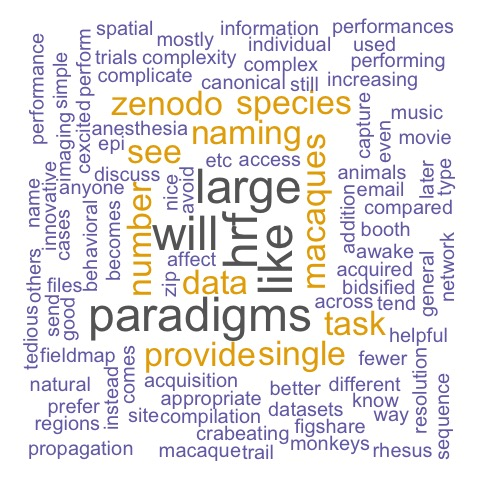

### Download

You can download an Excel spreadsheet with the survey responses [here](https://github.com/hotavocado/PRIME-info-request/blob/master/PRIME_survey_reponses.xlsx).